# Assignment 3: ML Exercise – Multiple Regression with TEDS 2016

Author

EPPS 6323 Knowledge Mining

Published

May 2, 2026

## Overview

This assignment uses the **Taiwan Election and Democratization Study (TEDS) 2016** dataset to explore multiple regression, build a custom plotting function, and critically evaluate the limits of OLS when the dependent variable is binary.

## 1. Setup and Data Loading

```r
library(haven)
library(ggplot2)
library(dplyr)

# Load the TEDS 2016 dataset
TEDS_2016 <- read_stata(
  "https://github.com/datageneration/home/blob/master/DataProgramming/data/TEDS_2016.dta?raw=true"
)
```

## 2. Exploring the Dataset

```r
# Quick overview
dim(TEDS_2016)
```

```
[1] 1690   54
```

```r
names(TEDS_2016)
```

```
 [1] "District"        "Sex"             "Age"             "Edu"
 [5] "Arear"           "Career"          "Career8"         "Ethnic"
 [9] "Party"           "PartyID"         "Tondu"           "Tondu3"
[13] "nI2"             "votetsai"        "green"           "votetsai_nm"
[17] "votetsai_all"    "Independence"    "Unification"     "sq"
[21] "Taiwanese"       "edu"             "female"          "whitecollar"
[25] "lowincome"       "income"          "income_nm"       "age"
[29] "KMT"             "DPP"             "npp"             "noparty"
[33] "pfp"             "South"           "north"           "Minnan_father"
[37] "Mainland_father" "Econ_worse"      "Inequality"      "inequality5"
[41] "econworse5"      "Govt_for_public" "pubwelf5"        "Govt_dont_care"
[45] "highincome"      "votekmt"         "votekmt_nm"      "Blue"
[49] "Green"           "No_Party"        "voteblue"        "voteblue_nm"
[53] "votedpp_1"       "votekmt_1"
```

```r
# Key variables
str(TEDS_2016[, c("votetsai", "age", "edu", "income")])
```

```
tibble [1,690 × 4] (S3: tbl_df/tbl/data.frame)
 $ votetsai: num [1:1690] NA 1 0 NA NA 1 1 1 1 NA ...
  ..- attr(*, "format.stata")= chr "%9.0g"
 $ age     : num [1:1690] 59 39 63 55 76 64 75 54 64 59 ...
  ..- attr(*, "format.stata")= chr "%9.0g"
 $ edu     : num [1:1690] 4 5 5 2 1 2 1 5 1 1 ...
  ..- attr(*, "format.stata")= chr "%9.0g"
 $ income  : num [1:1690] 8 7 8 5 5.5 9 1 10 2 5.5 ...
  ..- attr(*, "format.stata")= chr "%9.0g"
```

```r
# Distribution of the dependent variable
table(TEDS_2016$votetsai, useNA = "always")
```

```
   0    1 <NA>
 471  790  429
```

The **dependent variable** is `votetsai` — whether a respondent voted for Tsai Ing-wen in the 2016 presidential election.

## 3. Multiple Regression Model

We run a multiple regression model predicting `votetsai` from `age`, `edu` (education), and `income`.

```r
model <- lm(votetsai ~ age + edu + income, data = TEDS_2016, na.action = na.omit)
summary(model)
```

```
Call:
lm(formula = votetsai ~ age + edu + income, data = TEDS_2016,
    na.action = na.omit)

Residuals:
    Min      1Q  Median      3Q     Max
-0.8095 -0.5806  0.3123  0.3751  0.6035

Coefficients:
             Estimate Std. Error t value Pr(>|t|)
(Intercept)  1.085494   0.085071  12.760  < 2e-16 ***
age         -0.005045   0.001058  -4.766 2.10e-06 ***
edu         -0.055280   0.012286  -4.499 7.45e-06 ***
income      -0.004692   0.005155  -0.910    0.363
---
Signif. codes:  0 '***' 0.001 '**' 0.01 '*' 0.05 '.' 0.1 ' ' 1

Residual standard error: 0.4789 on 1253 degrees of freedom
  (433 observations deleted due to missingness)
Multiple R-squared:  0.02362,   Adjusted R-squared:  0.02128
F-statistic:  10.1 on 3 and 1253 DF,  p-value: 1.407e-06
```

**Interpretation:** The OLS model estimates the linear relationship between each predictor and the probability of voting for Tsai. However, as we will see below, using OLS with a binary outcome has fundamental problems.

## 4. The `regplot` Function

We define a custom function that combines `lm()`, `plot()`, and `abline()` to produce a simple regression fit plot.

```r
## Creating a function: regplot
## Combines lm, plot, and abline to create a regression fit plot

regplot <- function(x, y, xlab = "Predictor", ylab = "votetsai",
                    main = "Regression Fit") {
  fit <- lm(y ~ x)
  plot(x, y,
    xlab  = xlab,
    ylab  = ylab,
    main  = main,
    pch   = 16,
    col   = rgb(0.2, 0.4, 0.8, 0.3),
    cex   = 0.7
  )
  abline(fit, col = "red", lwd = 2)
}
```

## 5. Regression Plots

### 5a. `votetsai` ~ Age

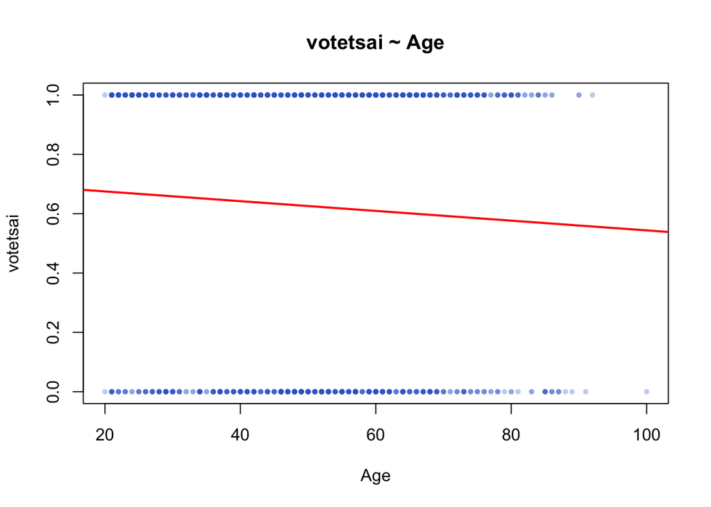

Linear regression of votetsai on Age

```r
regplot(
  x    = TEDS_2016$age,
  y    = TEDS_2016$votetsai,
  xlab = "Age",
  main = "votetsai ~ Age"
)
```

### 5b. `votetsai` ~ Education

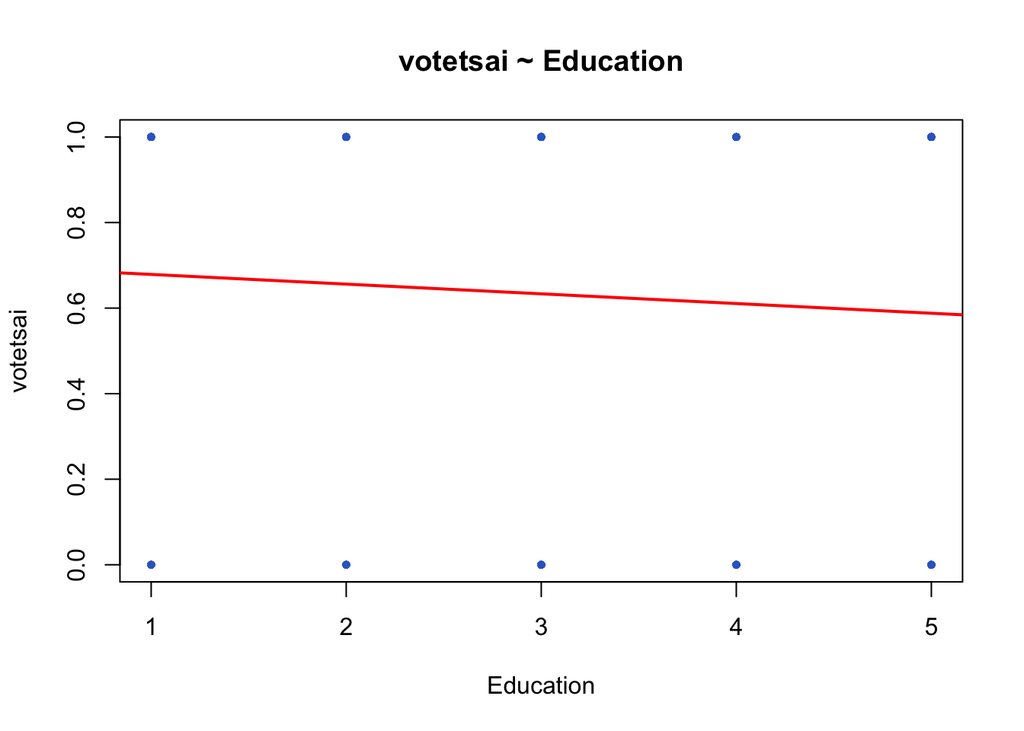

Linear regression of votetsai on Education

```r
regplot(
  x    = TEDS_2016$edu,
  y    = TEDS_2016$votetsai,
  xlab = "Education",
  main = "votetsai ~ Education"
)
```

### 5c. `votetsai` ~ Income

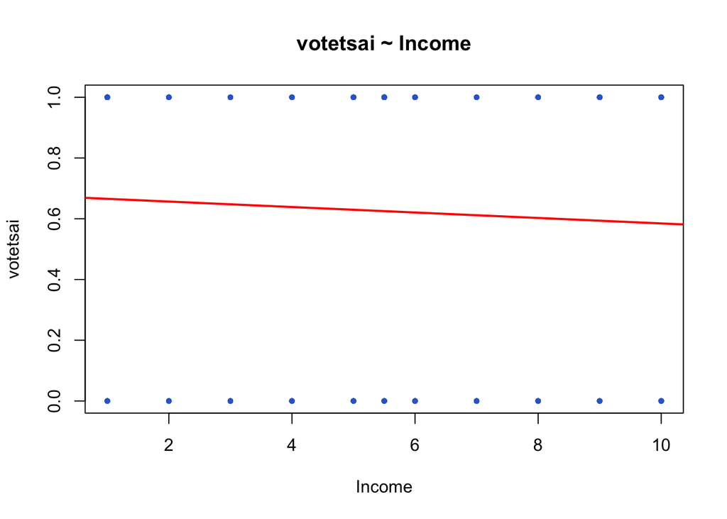

Linear regression of votetsai on Income

```r
regplot(
  x    = TEDS_2016$income,
  y    = TEDS_2016$votetsai,
  xlab = "Income",
  main = "votetsai ~ Income"
)
```

## 6. What Is the Problem? Why?

### The Core Issue: Binary Dependent Variable

The dependent variable `votetsai` takes only **two values: 0 and 1**:

- **0** = Did *not* vote for Tsai Ing-wen
- **1** = Did vote for Tsai Ing-wen

This creates **three critical problems** when using Ordinary Least Squares (OLS):

| Problem | Explanation |
| --- | --- |
| **Out-of-range predictions** | OLS can produce predicted values below 0 or above 1, which are nonsensical as probabilities |
| **Non-linear relationship** | The true relationship between predictors and a binary outcome is inherently S-shaped (sigmoid), not linear |
| **Heteroskedasticity** | With a binary outcome, the variance of errors depends on the predicted value — a core OLS assumption is violated |

The scatter plots make this visually clear: all the data points lie on **two horizontal bands** (y = 0 and y = 1), and the red regression line cuts awkwardly through them. No amount of tuning the OLS model will fix this structural mismatch.

> **In short:** OLS was designed for continuous outcomes. Forcing it onto a binary outcome produces inefficient estimates and uninterpretable predictions.

## 7. How to Improve Prediction of the Dependent Variable

### Recommended Approach: Logistic Regression

Since `votetsai` is binary, the appropriate model is **logistic regression** (a Generalized Linear Model with a binomial family and logit link). It models the **log-odds** of voting for Tsai, keeping all predicted probabilities between 0 and 1.

```r
logit_model <- glm(
  votetsai ~ age + edu + income,
  data   = TEDS_2016,
  family = binomial(link = "logit"),
  na.action = na.omit
)

summary(logit_model)
```

```
Call:
glm(formula = votetsai ~ age + edu + income, family = binomial(link = "logit"),
    data = TEDS_2016, na.action = na.omit)

Coefficients:
             Estimate Std. Error z value Pr(>|z|)
(Intercept)  2.508583   0.379569   6.609 3.87e-11 ***
age         -0.021731   0.004656  -4.668 3.05e-06 ***
edu         -0.238448   0.054069  -4.410 1.03e-05 ***
income      -0.020470   0.022460  -0.911    0.362
---
Signif. codes:  0 '***' 0.001 '**' 0.01 '*' 0.05 '.' 0.1 ' ' 1

(Dispersion parameter for binomial family taken to be 1)

    Null deviance: 1661.8  on 1256  degrees of freedom
Residual deviance: 1632.0  on 1253  degrees of freedom
  (433 observations deleted due to missingness)
AIC: 1640

Number of Fisher Scoring iterations: 4
```

### Model Comparison

```r
# Predicted probabilities from logistic regression
pred_probs <- predict(logit_model, type = "response")

# Classification accuracy using 0.5 threshold
predicted_class <- ifelse(pred_probs >= 0.5, 1, 0)
actual <- as.numeric(TEDS_2016$votetsai[!is.na(TEDS_2016$votetsai) &
                                         !is.na(TEDS_2016$age) &
                                         !is.na(TEDS_2016$edu) &
                                         !is.na(TEDS_2016$income)])

accuracy <- mean(predicted_class == actual, na.rm = TRUE)
cat("Logistic Regression Accuracy:", round(accuracy * 100, 1), "%\n")
```

```
Logistic Regression Accuracy: 63.1 %
```

```r
# Confusion matrix
table(Predicted = predicted_class, Actual = actual)
```

```
         Actual
Predicted   0   1
        0  45  39
        1 425 748
```

### Visualizing Logistic Fit

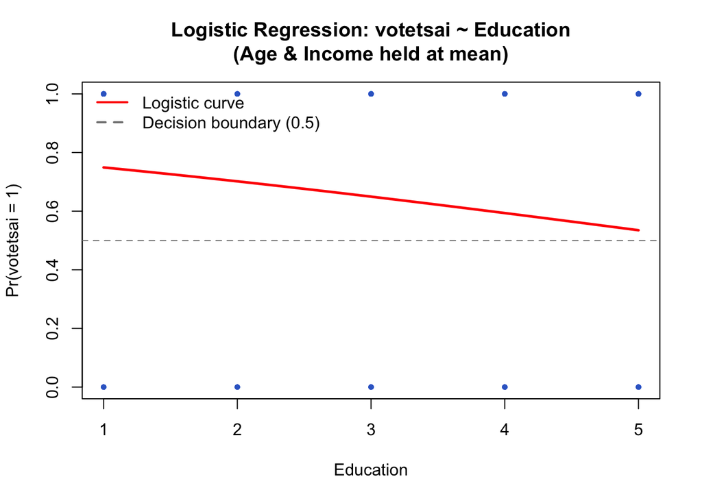

Logistic regression fit of votetsai on Education

```r
# Use education as the focal predictor for visualization
edu_range <- seq(min(TEDS_2016$edu, na.rm = TRUE),
                 max(TEDS_2016$edu, na.rm = TRUE), length.out = 200)

# Predict with mean age and income held constant
newdata <- data.frame(
  edu    = edu_range,
  age    = mean(TEDS_2016$age,    na.rm = TRUE),
  income = mean(TEDS_2016$income, na.rm = TRUE)
)
newdata$prob <- predict(logit_model, newdata = newdata, type = "response")

plot(TEDS_2016$edu, TEDS_2016$votetsai,
     xlab = "Education",
     ylab = "Pr(votetsai = 1)",
     main = "Logistic Regression: votetsai ~ Education\n(Age & Income held at mean)",
     pch  = 16,
     col  = rgb(0.2, 0.4, 0.8, 0.2),
     cex  = 0.7)

lines(newdata$edu, newdata$prob, col = "red", lwd = 2.5)
abline(h = 0.5, col = "gray50", lty = 2)
legend("topleft",
       legend = c("Logistic curve", "Decision boundary (0.5)"),
       col    = c("red", "gray50"),
       lty    = c(1, 2), lwd = 2, bty = "n")
```

### Summary of Improvements

| Approach | Why it helps |
| --- | --- |
| **Logistic Regression** | Constrains predictions to [0,1]; models non-linear probability |
| **Add more predictors** | Include party ID, political attitudes (e.g., `tomiddle`, `unification`) to improve fit |
| **Interaction terms** | e.g., `age × education` may capture nuanced effects |
| **Regularization (LASSO/Ridge)** | Handles multicollinearity if many predictors are added |
| **Tree-based models** | Random Forest or boosting can capture complex non-linearities |